# Multiple Imputation with the mice package

## Getting to know the data

The first steps are to load the package `mice` and the data we want to impute. For this example, we will use the **NHANES** dataset.

To load this dataset, you can use the command `file.choose()` which opens the explorer and allows you to navigate to the location of the file `NHANES_1.RData`. If you know the path to the file, you can also use `load("<path>/NHANES_1.RData")`.

**Note:**  
To display the help file for any function, type a `?` followed by the name of the function in one of the code fields and click on “Run Code”.

Alternatively, you can look up the help pages online at https://www.rdocumentation.org/ or find the whole manual for a package at https://cran.r-project.org/web/packages/available_packages_by_name.html

### Dataset

#### Task

The **mice** package needs to be loaded with the command `library()`. Let’s take a first look at the data. Useful functions are `dim()`, `head()`, `str()` and `summary()`.

#### Solution

```r
library(mice)
dim(NHANES)
```

```
## [1] 1000   23
```

```r
head(NHANES)
```

|  | height | BMI | hypten | DM | cohort | DBP | bili | SBP | hypchol | creat | WC | age | HyperMed | weight | chol | educ | alc | albu | race | HDL | uricacid | smoke | gender |
| --- | --- | --- | --- | --- | --- | --- | --- | --- | --- | --- | --- | --- | --- | --- | --- | --- | --- | --- | --- | --- | --- | --- | --- |
| 836 | 1.6510 | 22.46493 | no | no | 2011 | 74.66667 | NA | 131.3333 | NA | NA | 79.2 | 61 | NA | 61.23492 | NA | High school graduate | 0 | NA | Mexican American | NA | NA | former | male |
| 285 | 1.8034 | 24.40728 | no | no | 2011 | 73.33333 | NA | 122.6667 | NA | NA | 89.4 | 20 | NA | 79.37860 | NA | High school graduate | 3-7 | NA | other | NA | NA | former | male |
| 2721 | 1.6510 | 17.97194 | no | no | 2011 | 75.33333 | 1.0 | 105.3333 | no | 0.96 | 70.2 | 24 | NA | 48.98794 | 4.99 | High school graduate | NA | 4.0 | Non-Hispanic White | 1.34 | 4.4 | never | female |
| 2308 | 1.6764 | 22.59634 | no | no | 2011 | 68.66667 | 0.5 | 123.3333 | no | 0.75 | 89.9 | 30 | NA | 63.50288 | 4.84 | some college | >7 | 4.7 | other | 2.02 | 5.0 | never | female |
| 1175 | 1.5748 | 30.17856 | no | no | 2011 | 82.66667 | NA | 125.3333 | NA | NA | 105.2 | 61 | NA | 74.84268 | NA | College or above | 1-3 | NA | Other Hispanic | NA | NA | never | female |
| 2527 | 1.6764 | 40.35061 | no | no | 2011 | 82.00000 | 0.6 | 106.0000 | no | 0.70 | 138.2 | 26 | NA | 113.39800 | 4.78 | some college | >7 | 4.1 | other | 1.22 | 7.3 | current | female |

```r
str(NHANES)
```

```
## 'data.frame':    1000 obs. of  23 variables:
##  $ height  : num  1.65 1.8 1.65 1.68 1.57 ...
##  $ BMI     : num  22.5 24.4 18 22.6 30.2 ...
##  $ hypten  : Factor w/ 2 levels "no","yes": 1 1 1 1 1 1 NA 1 2 1 ...
##  $ DM      : Factor w/ 2 levels "no","yes": 1 1 1 1 1 1 1 1 2 1 ...
##  $ cohort  : chr  "2011" "2011" "2011" "2011" ...
##  $ DBP     : num  74.7 73.3 75.3 68.7 82.7 ...
##  $ bili    : num  NA NA 1 0.5 NA 0.6 1.1 0.6 0.4 0.9 ...
##  $ SBP     : num  131 123 105 123 125 ...
##  $ hypchol : Factor w/ 2 levels "no","yes": NA NA 1 1 NA 1 1 1 1 1 ...
##  $ creat   : num  NA NA 0.96 0.75 NA 0.7 0.72 0.86 0.6 0.94 ...
##  $ WC      : num  79.2 89.4 70.2 89.9 105.2 ...
##  $ age     : num  61 20 24 30 61 26 61 48 57 40 ...
##  $ HyperMed: Ord.factor w/ 3 levels "no"<"previous"<..: NA NA NA NA NA NA NA NA 3 NA ...
##  $ weight  : num  61.2 79.4 49 63.5 74.8 ...
##  $ chol    : num  NA NA 4.99 4.84 NA 4.78 4.09 4.84 4.68 4.86 ...
##  $ educ    : Factor w/ 5 levels "Less than 9th grade",..: 3 3 3 4 5 4 2 3 5 1 ...
##  $ alc     : Ord.factor w/ 5 levels "0"<"<=1"<"1-3"<..: 1 4 NA 5 3 5 3 5 2 4 ...
##  $ albu    : num  NA NA 4 4.7 NA 4.1 4.8 4.3 3.5 4.3 ...
##  $ race    : Factor w/ 5 levels "Mexican American",..: 1 5 3 5 2 5 5 3 3 3 ...
##  $ HDL     : num  NA NA 1.34 2.02 NA 1.22 1.32 1.09 0.8 1.5 ...
##  $ uricacid: num  NA NA 4.4 5 NA 7.3 5.8 5.2 5 4.9 ...
##  $ smoke   : Ord.factor w/ 3 levels "never"<"former"<..: 2 2 1 1 1 3 2 3 1 3 ...
##  $ gender  : Factor w/ 2 levels "male","female": 1 1 2 2 2 2 1 1 2 1 ...
```

```r
summary(NHANES)
```

```
##      height           BMI         hypten      DM         cohort
##  Min.   :1.397   Min.   :16.27   no  :637   no :843   Length:1000
##  1st Qu.:1.600   1st Qu.:23.33   yes :335   yes:157   Class :character
##  Median :1.676   Median :26.61   NA's: 28             Mode  :character
##  Mean   :1.679   Mean   :27.71
##  3rd Qu.:1.753   3rd Qu.:30.67
##  Max.   :1.930   Max.   :62.35
##  NA's   :20      NA's   :30
##       DBP              bili             SBP         hypchol
##  Min.   : 12.67   Min.   :0.2000   Min.   : 81.33   no  :815
##  1st Qu.: 64.00   1st Qu.:0.6000   1st Qu.:108.67   yes :100
##  Median : 70.67   Median :0.7000   Median :118.00   NA's: 85
##  Mean   : 70.50   Mean   :0.7492   Mean   :120.25
##  3rd Qu.: 77.33   3rd Qu.:0.9000   3rd Qu.:128.67
##  Max.   :110.00   Max.   :4.1000   Max.   :207.33
##  NA's   :41       NA's   :87       NA's   :41
##      creat              WC              age            HyperMed
##  Min.   :0.3400   Min.   : 64.50   Min.   :20.00   no      : 29
##  1st Qu.:0.6900   1st Qu.: 85.00   1st Qu.:32.00   previous: 28
##  Median :0.8200   Median : 94.95   Median :45.00   yes     :213
##  Mean   :0.8559   Mean   : 96.59   Mean   :46.54   NA's    :730
##  3rd Qu.:0.9600   3rd Qu.:105.78   3rd Qu.:60.00
##  Max.   :7.4600   Max.   :152.40   Max.   :79.00
##  NA's   :86       NA's   :50
##      weight            chol                        educ       alc
##  Min.   : 38.56   Min.   :2.07   Less than 9th grade : 78   0   :139
##  1st Qu.: 63.50   1st Qu.:4.34   9-11th grade        :157   <=1 :276
##  Median : 76.66   Median :4.99   High school graduate:216   1-3 :113
##  Mean   : 78.44   Mean   :5.02   some college        :289   3-7 : 82
##  3rd Qu.: 89.36   3rd Qu.:5.61   College or above    :259   >7  :114
##  Max.   :167.83   Max.   :9.93   NA's                :  1   NA's:276
##  NA's   :17       NA's   :85
##       albu                       race          HDL           uricacid
##  Min.   :2.600   Mexican American  : 96   Min.   :0.360   Min.   : 1.800
##  1st Qu.:4.100   Other Hispanic    :110   1st Qu.:1.110   1st Qu.: 4.400
##  Median :4.300   Non-Hispanic White:356   Median :1.340   Median : 5.400
##  Mean   :4.277   Non-Hispanic Black:243   Mean   :1.388   Mean   : 5.406
##  3rd Qu.:4.500   other             :195   3rd Qu.:1.580   3rd Qu.: 6.300
##  Max.   :5.200                            Max.   :3.570   Max.   :11.000
##  NA's   :86                               NA's   :85      NA's   :86
##      smoke        gender
##  never  :574   male  :476
##  former :213   female:524
##  current:212
##  NA's   :  1
##
##
##
```

### Variable coding

It is important to check that all variables are coded correctly, i.e., have the correct variable `class` specified, because `mice()` automatically selects imputation methods based on each variable’s `class`. When importing data from other software it can happen that factors become continuous variables or that ordered factors lose their ordering.

`str()` showed that in the NHANES data `smoke` and `alc` are correctly specified as ordinal variables, but `educ` is an unordered factor.

#### Task

Using `levels(NHANES$educ)` we can print the names of the categories of `educ`. Convert the unordered factor to an ordered factor, for example using `as.ordered()`. Afterwards, check if the conversion was successful.

#### Solution

```r
levels(NHANES$educ)
```

```
## [1] "Less than 9th grade"  "9-11th grade"         "High school graduate"
## [4] "some college"         "College or above"
```

```r
NHANES$educ <- as.ordered(NHANES$educ)

str(NHANES$educ)
```

```
##  Ord.factor w/ 5 levels "Less than 9th grade"<..: 3 3 3 4 5 4 2 3 5 1 ...
```

### Missing data pattern

In the `summary()` we could already see that there are missing values in several variables. The function `md.pattern()` allows us to further investigate the missing data pattern.

#### Task 1

Explore the missing data pattern of the NHANES data.

#### Solution 1

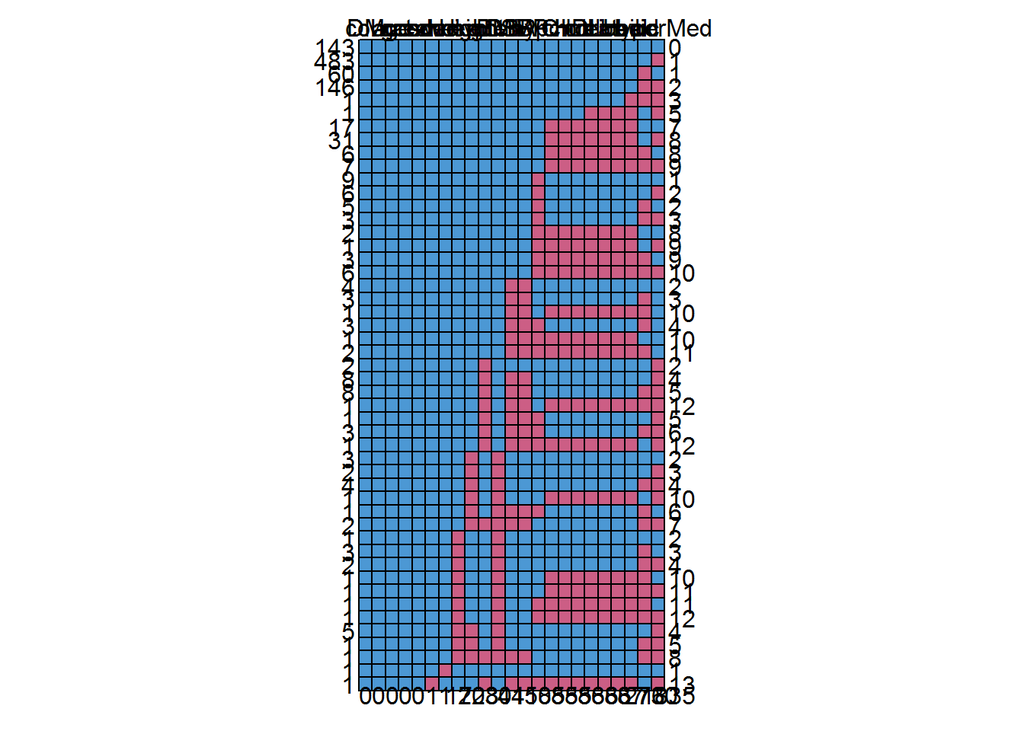

```r
mdp <- md.pattern(NHANES)
```

```r
mdp
```

```
##     DM cohort age race gender educ smoke weight height hypten BMI DBP SBP
## 143  1      1   1    1      1    1     1      1      1      1   1   1   1
## 483  1      1   1    1      1    1     1      1      1      1   1   1   1
## 60   1      1   1    1      1    1     1      1      1      1   1   1   1
## 146  1      1   1    1      1    1     1      1      1      1   1   1   1
## 1    1      1   1    1      1    1     1      1      1      1   1   1   1
## 1    1      1   1    1      1    1     1      1      1      1   1   1   1
## 17   1      1   1    1      1    1     1      1      1      1   1   1   1
## 31   1      1   1    1      1    1     1      1      1      1   1   1   1
## 6    1      1   1    1      1    1     1      1      1      1   1   1   1
## 7    1      1   1    1      1    1     1      1      1      1   1   1   1
## 9    1      1   1    1      1    1     1      1      1      1   1   1   1
## 6    1      1   1    1      1    1     1      1      1      1   1   1   1
## 5    1      1   1    1      1    1     1      1      1      1   1   1   1
## 3    1      1   1    1      1    1     1      1      1      1   1   1   1
```

[output cut: 87 more lines]

`md.pattern()` gives us a matrix where each row represents one missing data pattern (1 = observed, 0 = missing). The rownames show how many rows of the data have the given missing data pattern. The last column gives the number of missing values in the pattern, the last row the number of missing values per variable.

#### Task 2

Visualize and inspect the missing data pattern using one or more of the examples shown in the course slides.

**Hint:** Some functions you can try are `JointAI::md_pattern()`, `VIM::aggr()`, `visdat::vis_dat()`, `visdat::vis_miss()`.

For `JointAI::md_pattern()` you can customize the y-axis by using the argument `yaxis_pars`, which is a list of arguments. To hide the counts use `yaxis_pars = list(yaxt = "n")` and `printN = FALSE`. To prevent the printed output use `print = FALSE`.

For more options check out the help pages of the functions.

#### Task 3

Now get an overview of how much missingness there is in each variable and the proportion of (in)complete cases.

The function `complete.cases()` will give you a vector that is TRUE if the the case is complete and FALSE if there are missing values.

`is.na()` returns `TRUE` if the value is missing, `FALSE` if the value is observed

`colSums()` calculates the sum of values in each column of a data.frame or matrix

`colMeans()` calculates the mean of values in each column of a data.frame or matrix

#### Solution 3

```r
# number and proportion of complete cases
Ncc <- cbind(
  "#" = table(complete.cases(NHANES)),
  "%" = round(100 * table(complete.cases(NHANES))/nrow(NHANES), 2)
)
rownames(Ncc) <- c("incompl.", "complete")
Ncc
```

```
##            #    %
## incompl. 857 85.7
## complete 143 14.3
```

```r
# number and proportion of missing values per variable
cbind("# NA" = sort(colSums(is.na(NHANES))),
      "% NA" = round(sort(colMeans(is.na(NHANES))) * 100, 2))
```

```
##          # NA % NA
## DM          0  0.0
## cohort      0  0.0
## age         0  0.0
## race        0  0.0
## gender      0  0.0
## educ        1  0.1
## smoke       1  0.1
## weight     17  1.7
## height     20  2.0
## hypten     28  2.8
## BMI        30  3.0
## DBP        41  4.1
## SBP        41  4.1
## WC         50  5.0
## hypchol    85  8.5
## chol       85  8.5
## HDL        85  8.5
## creat      86  8.6
## albu       86  8.6
## uricacid   86  8.6
## bili       87  8.7
## alc       276 27.6
## HyperMed  730 73.0
```

#### Task 4

Our data contains `height`, `weight` and `BMI`. Check the missing data pattern specifically for those three variables.

#### Solution 4

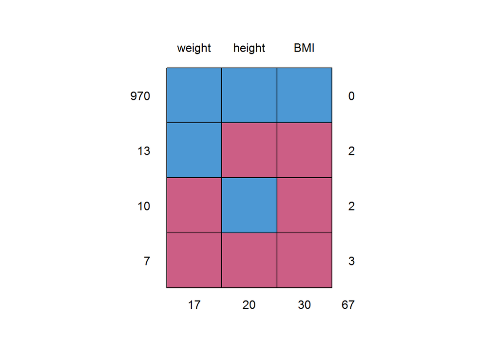

```
##     weight height BMI
## 970      1      1   1  0
## 13       1      0   0  2
## 10       0      1   0  2
## 7        0      0   0  3
##         17     20  30 67
```

```r
# Three solutions to choose from:
md.pattern(NHANES[, c("height", "weight", "BMI")])
```

```r
with(NHANES, table(is.na(height), is.na(weight), is.na(BMI)))
```

```
## , ,  = FALSE
##
##
##         FALSE TRUE
##   FALSE   970    0
##   TRUE      0    0
##
## , ,  = TRUE
##
##
##         FALSE TRUE
##   FALSE     0   10
##   TRUE     13    7
```

```r
library(plyr)
ddply(NHANES, c(height = "ifelse(is.na(height), 'missing', 'observed')",
                weight = "ifelse(is.na(weight), 'missing', 'observed')",
                BMI = "ifelse(is.na(BMI), 'missing', 'observed')"),
      summarize,
      N = length(height)
)
```

| height | weight | BMI | N |
| --- | --- | --- | --- |
| missing | missing | missing | 7 |
| missing | observed | missing | 13 |
| observed | missing | missing | 10 |
| observed | observed | observed | 970 |

As we have already seen in the lecture, there are quite a number of cases where only either `height` or `weight` is missing. `BMI` is only observed when both components are observed. To use all available information, we want to impute `height` and `weight` separately and calculate `BMI` from the imputed values.

#### Task 5

Because we might expect that hypertensive medication is only prescribed for patients with hypertension, we will also look into the variables `HyperMed` and `hypten`. Make a table of the two variables to confirm our expectation. Make sure that missing values are also displayed in that table!

#### Solution 5

```r
with(NHANES, table(HyperMed, hypten, exclude = NULL))
```

```
##           hypten
## HyperMed    no yes <NA>
##   no         0  29    0
##   previous   0  28    0
##   yes        0 213    0
##   <NA>     637  65   28
```

#### Task 6

Furthermore, we can expect a systematic relationship between `hypchol` and `chol`. Find out how these two variables are related.

#### Solution 6

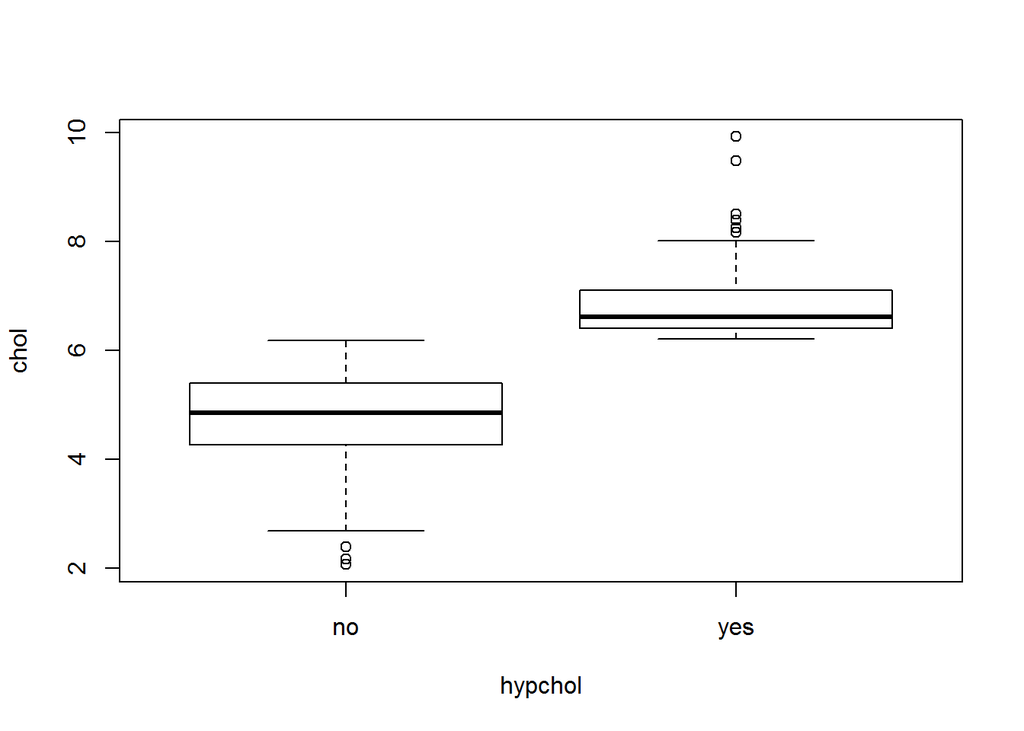

```r
with(NHANES, plot(chol ~ hypchol))
```

```r
with(NHANES, summary(chol[hypchol == "no"]))
```

```
##    Min. 1st Qu.  Median    Mean 3rd Qu.    Max.    NA's
##   2.070   4.270   4.860   4.795   5.400   6.180      85
```

```r
with(NHANES, summary(chol[hypchol == "yes"]))
```

```
##    Min. 1st Qu.  Median    Mean 3rd Qu.    Max.    NA's
##   6.210   6.410   6.620   6.854   7.110   9.930      85
```

It seems that `hypchol` is defined as having `chol > 6.2`, which makes `hypchol` dependent on `chol`.

### Distribution of the data

Before imputing the missing data it is important to take a look at how the incomplete variables are distributed so that we can choose appropriate imputation models.

#### Task

Visualize the distributions of the incomplete continuous and categorical variables. Pay attention to

- whether continuous distributions deviate considerably from the normal distribution,
- if variables have values close to the limits of the range they are defined in,
- whether categorical variables are very unbalanced (i.e., some category very small).

**Hint:** You may want to use the functions `hist()`, `table()` and `barplot()`.

Of course, you could also use the **ggplot2** package.

#### Solution

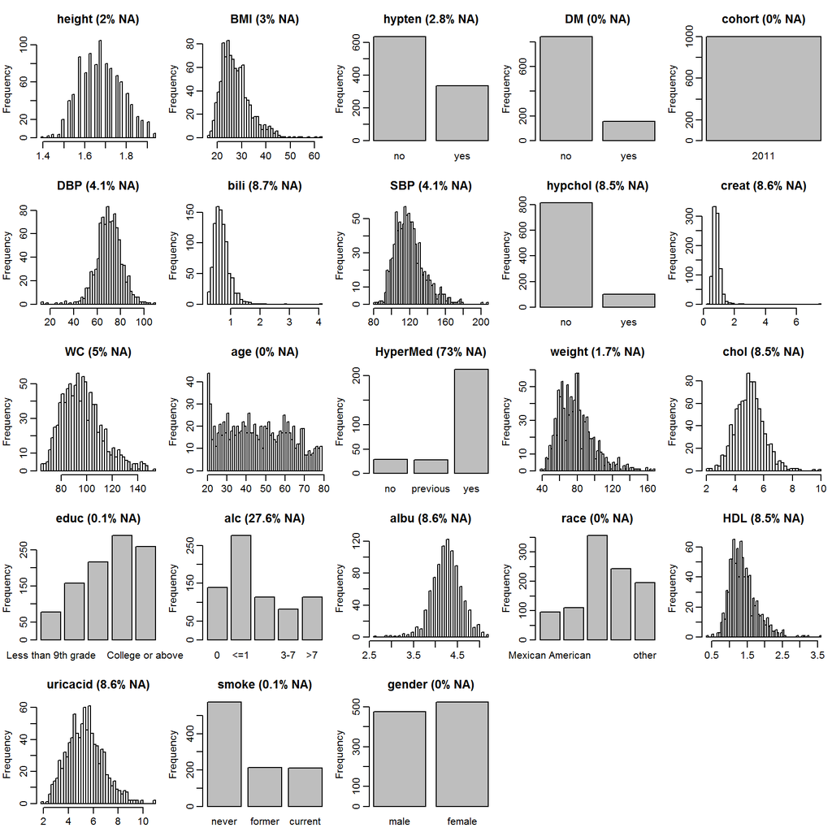

```r
# One option that allows to quickly get an overview of all variables,
# categorical and continuous

nc <- max(5, ceiling(sqrt(ncol(NHANES))))
nr <- ceiling(ncol(NHANES) / nc)
par(mfrow = c(nr, nc), mgp = c(2, 0.6, 0), mar = c(2, 3, 3, 0.5))
for (i in 1:ncol(NHANES)) {
  if (is.numeric(NHANES[, i])) {
    hist(NHANES[, i], nclass = 50, xlab = "",
         main = paste0(names(NHANES[i]), " (",
                       round(mean(is.na(NHANES[, i])) * 100, 2), "% NA)")
    )
  } else {
    barplot(table(NHANES[, i]), ylab = "Frequency",
            main = paste0(names(NHANES[i]), " (",
                          round(mean(is.na(NHANES[, i])) * 100, 2), "% NA)"))
  }
}
```

## Imputation

Now that we know how our data and the missing values are distributed, we are ready to impute!

### Set-up run

#### Task

First, do a set-up run of `mice()`, without any iterations (`maxit = 0`). This is to get all the objects that we may need to adjust in order to customize the imputation to our data.

If you need help to figure out what you need to specify take a look at the help page [`?mice`](https://www.rdocumentation.org/packages/mice/versions/2.46.0/topics/mice).

#### Solution

```r
imp0 <- mice(NHANES, maxit = 0)
```

Note: This command will not produce any output.

### Imputation method

There are many imputation methods available in **mice**. You can find the list in the help page of the `mice()` function. We will focus here on the following ones:

| name | description | variable type |
| --- | --- | --- |
| pmm | Predictive mean matching | any |
| norm | Bayesian linear regression | numeric |
| logreg | Logistic regression | factor, 2 levels |
| polyreg | Polytomous logistic regression | factor, >= 2 levels |
| polr | Proportional odds model | ordered, >= 2 levels |

The default imputation methods that `mice()` selects can be specified in the argument `defaultMethod`.

If unspecified, `mice` will use

- `pmm` for numerical columns,
- `logreg` for factor columns with two categories,
- `polyreg` for columns with unordered and
- `polr` for columns with ordered factors with more than two categories.

#### Task 1

When a normal imputation model seems to be appropriate for most of the continuous covariates, you may want to specify `norm` as the default method in the setup run. Let’s do that:

The order of the types of variable is: continuous, binary, factor, ordered factor.

#### Solution 1

```r
imp0 <- mice(NHANES, maxit = 0,
             defaultMethod = c("norm", 'logreg', 'polyreg', 'polr'))
```

#### Task 2

Looking at the histograms we made for the continuous variables, we can see that the variable `creat` has a skewed distribution, so using a normal imputation model may not work well.

Let’s change the imputation method for `creat` so that it is imputed with predictive mean matching:

#### Solution 2

```r
meth <- imp0$meth
meth["creat"] <- "pmm"
```

### Predictor matrix

#### Task 1

We can now check out if we need to make any changes to the `predictorMatrix` argument.

#### Solution 1

```r
pred <- imp0$predictorMatrix
pred
```

```
##          height BMI hypten DM cohort DBP bili SBP hypchol creat WC age
## height        0   1      1  1      0   1    1   1       1     1  1   1
## BMI           1   0      1  1      0   1    1   1       1     1  1   1
## hypten        1   1      0  1      0   1    1   1       1     1  1   1
## DM            1   1      1  0      0   1    1   1       1     1  1   1
## cohort        1   1      1  1      0   1    1   1       1     1  1   1
## DBP           1   1      1  1      0   0    1   1       1     1  1   1
## bili          1   1      1  1      0   1    0   1       1     1  1   1
## SBP           1   1      1  1      0   1    1   0       1     1  1   1
## hypchol       1   1      1  1      0   1    1   1       0     1  1   1
## creat         1   1      1  1      0   1    1   1       1     0  1   1
## WC            1   1      1  1      0   1    1   1       1     1  0   1
## age           1   1      1  1      0   1    1   1       1     1  1   0
## HyperMed      1   1      1  1      0   1    1   1       1     1  1   1
## weight        1   1      1  1      0   1    1   1       1     1  1   1
## chol          1   1      1  1      0   1    1   1       0     1  1   1
## educ          1   1      1  1      0   1    1   1       1     1  1   1
## alc           1   1      1  1      0   1    1   1       1     1  1   1
## albu          1   1      1  1      0   1    1   1       1     1  1   1
## race          1   1      1  1      0   1    1   1       1     1  1   1
## HDL           1   1      1  1      0   1    1   1       1     1  1   1
## uricacid      1   1      1  1      0   1    1   1       1     1  1   1
## smoke         1   1      1  1      0   1    1   1       1     1  1   1
## gender        1   1      1  1      0   1    1   1       1     1  1   1
##          HyperMed weight chol educ alc albu race HDL uricacid smoke gender
## height          1      1    1    1   1    1    1   1        1     1      1
## BMI             1      1    1    1   1    1    1   1        1     1      1
## hypten          1      1    1    1   1    1    1   1        1     1      1
## DM              1      1    1    1   1    1    1   1        1     1      1
## cohort          1      1    1    1   1    1    1   1        1     1      1
## DBP             1      1    1    1   1    1    1   1        1     1      1
## bili            1      1    1    1   1    1    1   1        1     1      1
## SBP             1      1    1    1   1    1    1   1        1     1      1
## hypchol         1      1    1    1   1    1    1   1        1     1      1
## creat           1      1    1    1   1    1    1   1        1     1      1
## WC              1      1    1    1   1    1    1   1        1     1      1
## age             1      1    1    1   1    1    1   1        1     1      1
## HyperMed        0      1    1    1   1    1    1   1        1     1      1
## weight          1      0    1    1   1    1    1   1        1     1      1
## chol            1      1    0    1   1    1    1   1        1     1      1
## educ            1      1    1    0   1    1    1   1        1     1      1
## alc             1      1    1    1   0    1    1   1        1     1      1
## albu            1      1    1    1   1    0    1   1        1     1      1
## race            1      1    1    1   1    1    0   1        1     1      1
## HDL             1      1    1    1   1    1    1   0        1     1      1
## uricacid        1      1    1    1   1    1    1   1        0     1      1
## smoke           1      1    1    1   1    1    1   1        1     0      1
## gender          1      1    1    1   1    1    1   1        1     1      0
```

#### Task 2

Remember that we wanted to impute `height` and `weight` separately? But let’s use `BMI` to impute the other variables. And since `HyperMed` does not give us a lot more information than `hypten`, but has a lot more missing values, we do not want to use it as a predictor variable.

Go ahead and apply the necessary changes to `pred` and `meth`:

For passive imputation, you need to specify the formula used to calculate BMI in meth using `"~I(...)"`.

#### Solution 2

```r
pred[c("height", "weight"), "BMI"] <- 0
pred[, c("height", "weight")] <- 0
pred["height", "weight"] <- 1
pred["weight", "height"] <- 1

pred[, "HyperMed"] <- 0

pred["chol", "hypchol"] <- 0


meth["BMI"] <- "~I(weight/height^2)"
meth["HyperMed"] <- ""
```

### Visit sequence

#### Task

To make sure that the imputed values of `BMI` match the imputed values of `height` and `weight`,`BMI` needs to be imputed after `height` and `weight`. Get the `visitSequence` from `imp0` (using `imp0$visitSequence`) and change it if necessary.

#### Solution

```r
visSeq <- imp0$visitSequence

# the lazy version:
visSeq <- c(visSeq[-2], visSeq[2])

# the save version:
# To make sure you still do the correct thing if the order of the columns in
# NHANES would change
which_BMI <- match("BMI", visSeq)
visSeq <- c(visSeq[-which_BMI], visSeq[which_BMI])
```

### Run the imputation

#### Task

With the changes that we have made to the `predictorMatrix` and `method`, we can now perform the imputation. Use `m = 5` and `maxit = 10`.

#### Solution

```r
imp <- mice(NHANES, method = meth, predictorMatrix = pred, visitSequence = visSeq,
            maxit = 10, m = 5,
            seed = 2018)
```

`mice()` prints the name of the variable being imputed for each iteration and imputation. If you run `mice()` on your own computer the output will show up continuously. There, you may notice that imputation is slowest for categorical variables, especially when they have many categories.

You can hide the lengthy output by specifying `printFlag = FALSE`.

## Investigate the imputation

### Type of class

#### Task

`mice()` does not return a `data.frame`. Find out the class of the object returned by `mice()` function using the function `class()`, and take a look at the [help file](https://www.rdocumentation.org/packages/mice/versions/2.46.0/topics/mids-class) for this class:

#### Solution

```r
class(imp)
```

```
## [1] "mids"
```

### Elements of the `mids` object

We see that `imp` is an object of class `mids`.

The [help file](https://www.rdocumentation.org/packages/mice/versions/2.46.0/topics/mids-class) tells us that a `mids` object is a list with several elements:

| `call`: | The call that created the `mids` object. |
| --- | --- |
| `data`: | A copy of the incomplete data set. |
| `where`: | The missingness indicator matrix. |
| `m`: | The number of imputations. |
| `nmis`: | The number of missing observations per variable. |
| `imp`: | The imputed values: A list of `ncol(data)` components,each list component is a matrix with `nmis[j]` rows and `m` columns. |
| `method`: | The vector imputation methods. |
| `predictorMatrix`: | The predictor matrix. |
| `visitSequence`: | The sequence in which columns are visited during imputation. |
| `post`: | A vector of strings of length `ncol(data)` with commands for post-processing. |
| `seed`: | The seed value of the solution. |
| `iteration`: | The number of iterations. |
| `lastSeedValue`: | The most recent seed value. |
| `chainMean:` | The mean of imputed values per variable and iteration: a list of `m` components. Each component is a matrix with `maxit`columns and `length(visitSequence)` rows. |
| `chainVar`: | The variances of imputed values per variable and iteration(same structure as `chainMean`). |
| `loggedEvents`: | A matrix with the record of automatic removal actions (details below); (`NULL` if no action was made). |
| `pad`: | A list containing the internally used version of the `data`,`method`, `predictorMatrix`, `visitSequence`, `post` and dummy coding. |

**Details of the `loggedEvents`:**

`mice()` does some pre-processing of the data:

- variables containing missing values, that are not imputed but used as predictor are removed
  - constant variables are removed
  - collinear variables are removed

Furthermore, during each iteration

- variables that are linearly dependent are removed
  - `polr` imputation that does not converge is replaced by `polyreg`.

The matrix in `loggedEvents` has the following columns:

| `it` | iteration number |
| --- | --- |
| `im` | imputation number |
| `co` | column number in the data |
| `dep` | name of the name of the variable being imputed |
| `meth` | imputation method used |
| `out` | character vector with names of altered/removed predictors |

#### Task

It is good practice to make sure that `mice()` has not done any processing of the data that was not planned or that you are not aware of. This means checking the `loggedEvents`, but also ensuring that the correct `method`, `predictorMatrix` and `visitSequence` were used.

Do these checks for `imp`.

#### Solution

```r
imp$method
```

```
##                height                   BMI                hypten
##                "norm" "~I(weight/height^2)"              "logreg"
##                    DM                cohort                   DBP
##                    ""                    ""                "norm"
##                  bili                   SBP               hypchol
##                "norm"                "norm"              "logreg"
##                 creat                    WC                   age
##                 "pmm"                "norm"                    ""
##              HyperMed                weight                  chol
##                    ""                "norm"                "norm"
##                  educ                   alc                  albu
##                "polr"                "polr"                "norm"
##                  race                   HDL              uricacid
##                    ""                "norm"                "norm"
##                 smoke                gender
##                "polr"                    ""
```

```r
imp$predictorMatrix
```

```
##          height BMI hypten DM cohort DBP bili SBP hypchol creat WC age
## height        0   0      1  1      0   1    1   1       1     1  1   1
## BMI           0   0      1  1      0   1    1   1       1     1  1   1
## hypten        0   1      0  1      0   1    1   1       1     1  1   1
## DM            0   1      1  0      0   1    1   1       1     1  1   1
## cohort        0   1      1  1      0   1    1   1       1     1  1   1
## DBP           0   1      1  1      0   0    1   1       1     1  1   1
## bili          0   1      1  1      0   1    0   1       1     1  1   1
## SBP           0   1      1  1      0   1    1   0       1     1  1   1
## hypchol       0   1      1  1      0   1    1   1       0     1  1   1
## creat         0   1      1  1      0   1    1   1       1     0  1   1
## WC            0   1      1  1      0   1    1   1       1     1  0   1
## age           0   1      1  1      0   1    1   1       1     1  1   0
## HyperMed      0   1      1  1      0   1    1   1       1     1  1   1
## weight        1   0      1  1      0   1    1   1       1     1  1   1
## chol          0   1      1  1      0   1    1   1       0     1  1   1
## educ          0   1      1  1      0   1    1   1       1     1  1   1
## alc           0   1      1  1      0   1    1   1       1     1  1   1
## albu          0   1      1  1      0   1    1   1       1     1  1   1
## race          0   1      1  1      0   1    1   1       1     1  1   1
## HDL           0   1      1  1      0   1    1   1       1     1  1   1
## uricacid      0   1      1  1      0   1    1   1       1     1  1   1
## smoke         0   1      1  1      0   1    1   1       1     1  1   1
## gender        0   1      1  1      0   1    1   1       1     1  1   1
##          HyperMed weight chol educ alc albu race HDL uricacid smoke gender
## height          0      1    1    1   1    1    1   1        1     1      1
## BMI             0      0    1    1   1    1    1   1        1     1      1
## hypten          0      0    1    1   1    1    1   1        1     1      1
## DM              0      0    1    1   1    1    1   1        1     1      1
## cohort          0      0    1    1   1    1    1   1        1     1      1
## DBP             0      0    1    1   1    1    1   1        1     1      1
## bili            0      0    1    1   1    1    1   1        1     1      1
## SBP             0      0    1    1   1    1    1   1        1     1      1
## hypchol         0      0    1    1   1    1    1   1        1     1      1
## creat           0      0    1    1   1    1    1   1        1     1      1
## WC              0      0    1    1   1    1    1   1        1     1      1
## age             0      0    1    1   1    1    1   1        1     1      1
## HyperMed        0      0    1    1   1    1    1   1        1     1      1
## weight          0      0    1    1   1    1    1   1        1     1      1
## chol            0      0    0    1   1    1    1   1        1     1      1
## educ            0      0    1    0   1    1    1   1        1     1      1
## alc             0      0    1    1   0    1    1   1        1     1      1
## albu            0      0    1    1   1    0    1   1        1     1      1
## race            0      0    1    1   1    1    0   1        1     1      1
## HDL             0      0    1    1   1    1    1   0        1     1      1
## uricacid        0      0    1    1   1    1    1   1        0     1      1
## smoke           0      0    1    1   1    1    1   1        1     0      1
## gender          0      0    1    1   1    1    1   1        1     1      0
```

```r
imp$visitSequence
```

```
##  [1] "height"   "hypten"   "DM"       "cohort"   "DBP"      "bili"
##  [7] "SBP"      "hypchol"  "creat"    "WC"       "age"      "HyperMed"
## [13] "weight"   "chol"     "educ"     "alc"      "albu"     "race"
## [19] "HDL"      "uricacid" "smoke"    "gender"   "BMI"
```

```r
imp$loggedEvents
```

[output not shown]

### Logged events

The `mice` help page told us that in case `polr` does not converge `polyreg` will be used.

#### Task 1

Find out if there is more information in the [help](https://www.rdocumentation.org/packages/mice/versions/2.46.0/topics/mice.impute.polr) [pages](https://www.rdocumentation.org/packages/mice/versions/2.46.0/topics/mice.impute.polyreg) for those two functions.

Using `polr` and `polyreg` when specifying the `method` argument in `mice` actually calls the functions `mice.impute.polr` and `mice.impute.polyreg` when running the imputation.

#### Solution 1

The help for `mice.impute.polr()` tells us:

> The call to `polr` might fail, usually because the data are very sparse. In that case, `multinom` is tried as a fallback, and a record is written to the `loggedEvents` component of the `mids` object.

and the help for `mice.impute.polyreg()` says:

> The algorithm of `mice.impute.polyreg` uses the function `multinom()` from the **nnet** package.

#### Task 2

Let’s see what else would have come up if we had not prepared the `predictorMatrix`, `method` and `visitSequence` before imputation. The object `impnaive` contains the result of

```r
impnaive <- mice(NHANES, m = 5, maxit = 10)
```

Take a look at the `loggedEvents` of `impnaive`.

#### Solution 2

```r
impnaive$loggedEvents
```

|  | it | im | dep | meth | out |
| --- | --- | --- | --- | --- | --- |
| 1 | 0 | 0 |  | constant | cohort |
| 2 | 1 | 1 | HyperMed | polr | hyptenyes |
| 3 | 1 | 2 | HyperMed | polr | hyptenyes |
| 4 | 1 | 3 | HyperMed | polr | hyptenyes |
| 5 | 1 | 4 | HyperMed | polr | hyptenyes |
| 6 | 1 | 5 | HyperMed | polr | hyptenyes |
| 7 | 2 | 1 | HyperMed | polr | hyptenyes |
| 8 | 2 | 2 | HyperMed | polr | hyptenyes |
| 9 | 2 | 3 | HyperMed | polr | hyptenyes |
| 10 | 2 | 4 | HyperMed | polr | hyptenyes |

[output cut: 41 more lines]

The `loggedEvents` of the “naive” imputation show that the constant variable `cohort` was excluded before the imputation (as it should be).

```r
impnaive$pad$categories
```

[output not shown]

#### Task 3

We also did not change the `visitSequence` in `impnaive`. Find out what the effects of that are.

#### Solution 3

```r
naiveDF1 <- complete(impnaive, 1)
naivecalcBMI <- with(naiveDF1, weight/height^2)

impDF1 <- complete(imp, 1)
impcalcBMI <- with(impDF1, weight/height^2)

cbind(naiveBMI = naiveDF1$BMI, naivecalcBMI,
      impBMI = impDF1$BMI, impcalcBMI)[which(is.na(NHANES$BMI)), ]
```

```
##       naiveBMI naivecalcBMI   impBMI impcalcBMI
##  [1,] 37.31167     39.05939 50.95614   50.95614
##  [2,] 30.72494     30.17856 26.48711   26.48711
##  [3,] 24.03068     23.77705 20.74845   20.74845
##  [4,] 33.81460     34.01090 37.55274   37.55274
##  [5,] 26.60836     26.07458 19.99553   19.99553
##  [6,] 23.17982     21.53987 21.55429   21.55429
##  [7,] 22.49821     23.56741 28.85095   28.85095
##  [8,] 25.50158     25.84813 28.91143   28.91143
##  [9,] 27.26186     27.34157 53.01660   53.01660
## [10,] 35.61107     36.55716 36.53027   36.53027
## [11,] 27.31942     26.52055 26.09882   26.09882
## [12,] 27.38756     27.39721 27.16814   27.16814
## [13,] 26.62510     25.88564 29.21529   29.21529
## [14,] 31.14421     30.89659 33.17403   33.17403
```

[output cut: 16 more lines]

When we compare the imputed and calculated values of `BMI` from `impnaive` we can see that the imputed `height` and `weight` give a different `BMI` than is imputed. This is because `BMI` is imputed before `weight`, which means that the most recent imputed value of `weight` is from the previous iteration.

Changing the `visitSequence` in `imp` prevented this inconsistency.

### Convergence

The mean and variance of the imputed values per iteration and variable is stored in the elements `chainMean` and `chainVar` of the `mids` object.

#### Task

Let’s plot them to see if our imputation `imp` has converged:

#### Solution

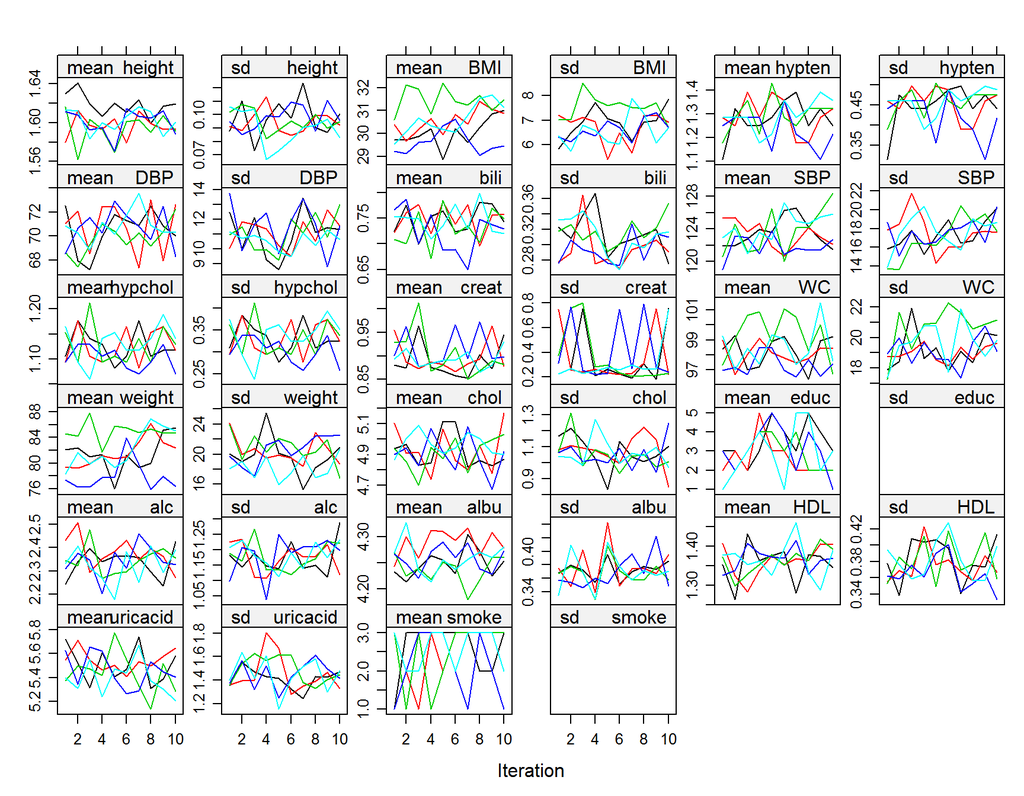

```r
# implemented plotting function (use layout to change the number of rows and columns)
plot(imp, layout = c(6, 6))
```

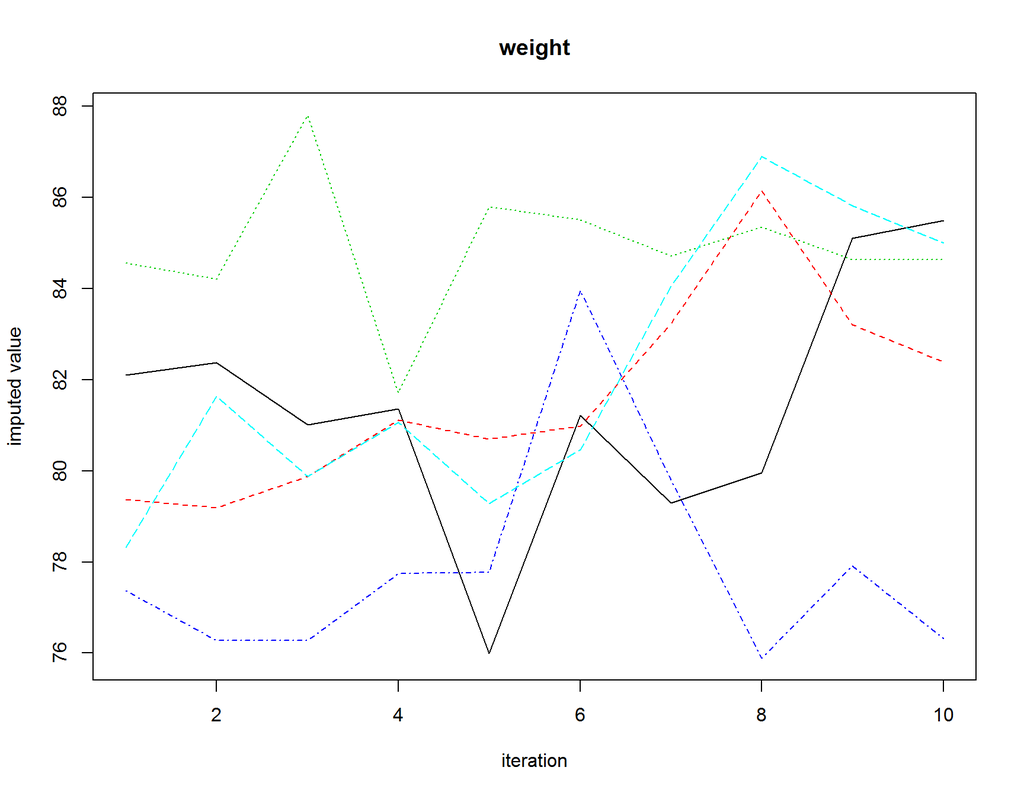

```r
# plot for a single variable
matplot(imp$chainMean["weight", , ], type = "l", ylab = "imputed value",
        xlab = "iteration", main = "weight")
```

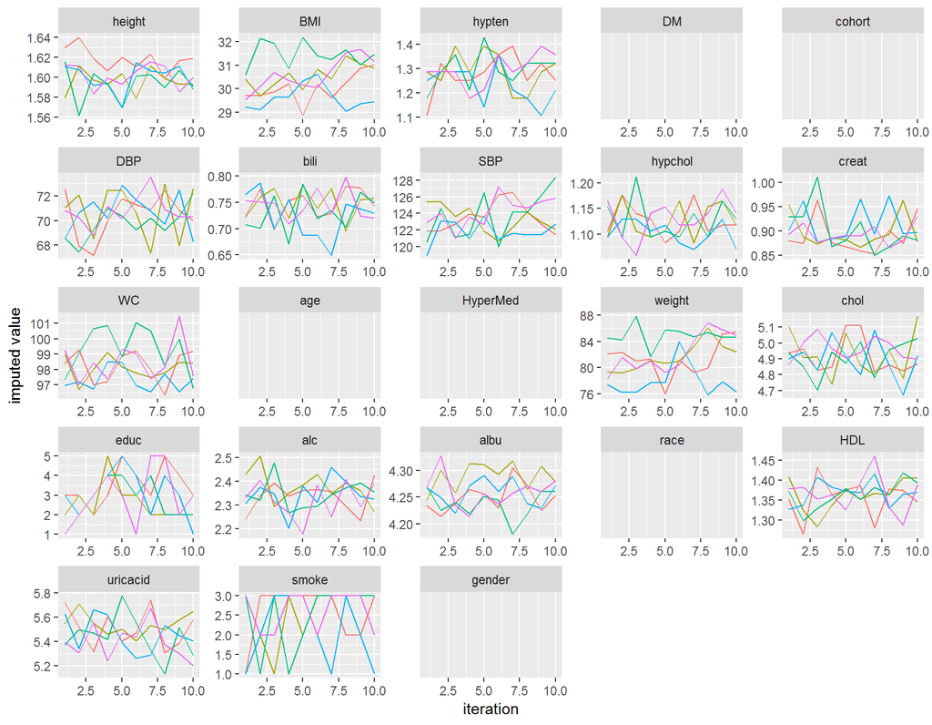

```r
# or the ggplot version
library(ggplot2)
library(reshape2)
ggplot(melt(imp$chainMean), aes(x = Var2, y = value, color = Var3)) +
  geom_line(na.rm = TRUE) +
  facet_wrap("Var1", scales = 'free') +
  theme(legend.position = 'none') +
  xlab("iteration") +
  ylab("imputed value")
```

The chains in `imp` seem to have converged, but in practice, more iterations should be done to confirm this.

#### Continue

In comparison, `impnaive` had some convergence problems:

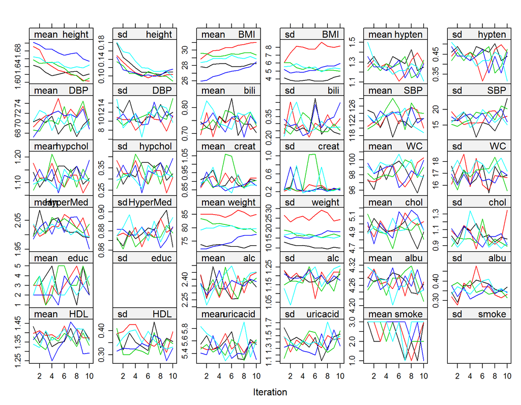

```r
plot(impnaive, layout = c(6, 6))
```

### Imputed values

Now that we know that `imp` has converged, we can compare the distribution of the imputed values against the distribution of the observed values.

#### Task

Plot the distributions of the imputed variables (continuous and categorical), and make sure the imputed values are realistic (e.g., no height of 2.50m or weight of 10kg for adults). If there are differences in the distributions of observed and imputed values see if those differences can be explained by other variables.

You can use `densityplot()` and `probplot()` to get plots for all continuous and categorical variables.

You can obtain `probplot()` from https://gist.github.com/NErler/0d00375da460dd33839b98faeee2fdab.

To check all imputed values you can either get a summary of the `imp` element of the `mids` object or create a complete dataset containing all imputations using the function `complete()` and get the summary of that.

#### Solution

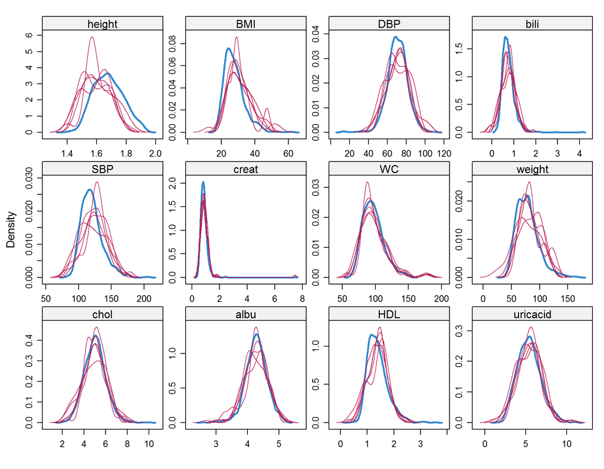

```r
densityplot(imp)
```

```r
# create a long dataset with all imputed data sets stacked onto each other
longDF <- complete(imp, "long")
summary(longDF)
```

```
##       .imp        .id             height           BMI        hypten
##  Min.   :1   Min.   :   1.0   Min.   :1.397   Min.   :12.21   no :3284
##  1st Qu.:2   1st Qu.: 250.8   1st Qu.:1.600   1st Qu.:23.40   yes:1716
##  Median :3   Median : 500.5   Median :1.676   Median :26.63
##  Mean   :3   Mean   : 500.5   Mean   :1.678   Mean   :27.80
##  3rd Qu.:4   3rd Qu.: 750.2   3rd Qu.:1.753   3rd Qu.:30.73
##  Max.   :5   Max.   :1000.0   Max.   :1.930   Max.   :62.35
##    DM          cohort               DBP              bili
##  no :4215   Length:5000        Min.   : 12.67   Min.   :-0.1626
##  yes: 785   Class :character   1st Qu.: 64.00   1st Qu.: 0.6000
##             Mode  :character   Median : 70.67   Median : 0.7000
##                                Mean   : 70.51   Mean   : 0.7484
##                                3rd Qu.: 77.33   3rd Qu.: 0.9000
##                                Max.   :110.00   Max.   : 4.1000
##       SBP        hypchol        creat              WC
##  Min.   : 78.4   no :4451   Min.   :0.3400   Min.   : 56.39
##  1st Qu.:108.7   yes: 549   1st Qu.:0.6900   1st Qu.: 84.95
##  Median :118.0              Median :0.8200   Median : 94.90
##  Mean   :120.4              Mean   :0.8602   Mean   : 96.65
##  3rd Qu.:129.3              3rd Qu.:0.9600   3rd Qu.:105.80
##  Max.   :207.3              Max.   :7.4600   Max.   :179.98
##       age            HyperMed        weight            chol
##  Min.   :20.00   no      : 145   Min.   : 28.35   Min.   :2.066
##  1st Qu.:32.00   previous: 140   1st Qu.: 63.50   1st Qu.:4.340
##  Median :45.00   yes     :1065   Median : 77.11   Median :4.990
##  Mean   :46.54   NA's    :3650   Mean   : 78.51   Mean   :5.016
##  3rd Qu.:60.00                   3rd Qu.: 89.36   3rd Qu.:5.610
##  Max.   :79.00                   Max.   :167.83   Max.   :9.930
##                    educ       alc            albu
##  Less than 9th grade : 391   0  :1024   Min.   :2.600
##  9-11th grade        : 787   <=1:2001   1st Qu.:4.100
##  High school graduate:1082   1-3: 745   Median :4.300
##  some college        :1445   3-7: 522   Mean   :4.276
##  College or above    :1295   >7 : 708   3rd Qu.:4.500
##                                         Max.   :5.236
##                  race           HDL            uricacid
##  Mexican American  : 480   Min.   :0.2962   Min.   : 0.9673
##  Other Hispanic    : 550   1st Qu.:1.1100   1st Qu.: 4.4000
##  Non-Hispanic White:1780   Median :1.3400   Median : 5.4000
##  Non-Hispanic Black:1215   Mean   :1.3875   Mean   : 5.4078
##  other             : 975   3rd Qu.:1.6000   3rd Qu.: 6.3000
##                            Max.   :3.5700   Max.   :11.0000
##      smoke         gender
##  never  :2871   male  :2380
##  former :1066   female:2620
##  current:1063
##
##
##
```

```r
# get the summary of the "raw" imputed values
lapply(imp$imp, function(x)
  summary(unlist(x))
)
```

```
## $height
##    Min. 1st Qu.  Median    Mean 3rd Qu.    Max.
##   1.400   1.529   1.585   1.598   1.673   1.813
##
## $BMI
##    Min. 1st Qu.  Median    Mean 3rd Qu.    Max.
##   12.21   26.08   29.20   30.79   34.85   53.02
##
## $hypten
##  no yes
##  99  41
##
## $DM
##    Mode
## logical
##
## $cohort
##    Mode
## logical
##
## $DBP
##    Min. 1st Qu.  Median    Mean 3rd Qu.    Max.
##   39.14   62.91   71.54   70.68   78.88  104.36
##
## $bili
##    Min. 1st Qu.  Median    Mean 3rd Qu.    Max.
## -0.1626  0.5289  0.7420  0.7398  0.9404  1.8591
##
## $SBP
##    Min. 1st Qu.  Median    Mean 3rd Qu.    Max.
##    78.4   110.7   125.2   124.1   137.1   178.1
##
## $hypchol
##  no yes
## 376  49
##
## $creat
##    Min. 1st Qu.  Median    Mean 3rd Qu.    Max.
##  0.3400  0.7100  0.8600  0.9063  1.0400  7.4600
##
```

[output cut: 38 more lines]

```
## $HDL
##    Min. 1st Qu.  Median    Mean 3rd Qu.    Max.
##  0.2962  1.1185  1.4179  1.3803  1.6160  2.5870
##
## $uricacid
##    Min. 1st Qu.  Median    Mean 3rd Qu.    Max.
##  0.9673  4.3912  5.4772  5.4238  6.3874 10.6634
##
## $smoke
##   never  former current
##       1       1       3
##
## $gender
##    Mode
## logical
```

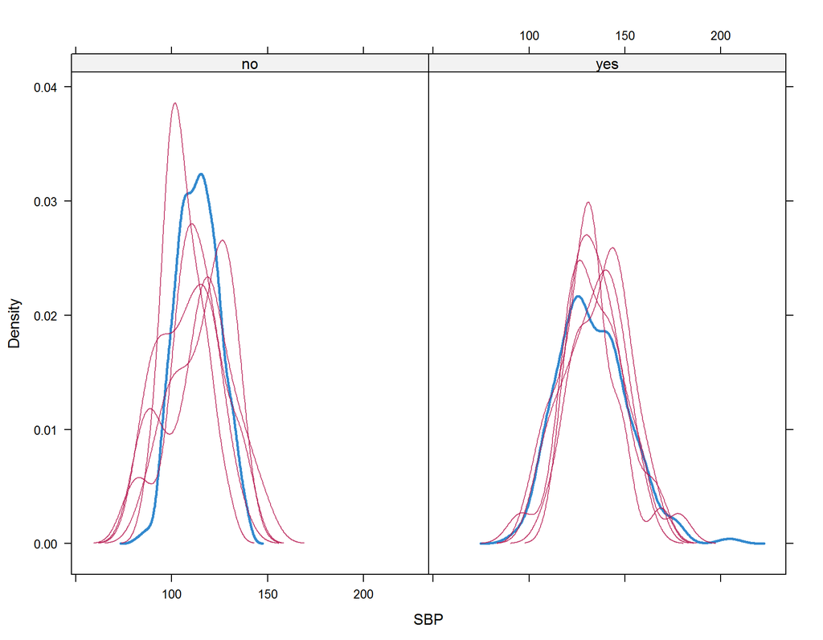

```r
# look into the distribution of SBP and height
densityplot(imp, ~SBP|hypten)
```

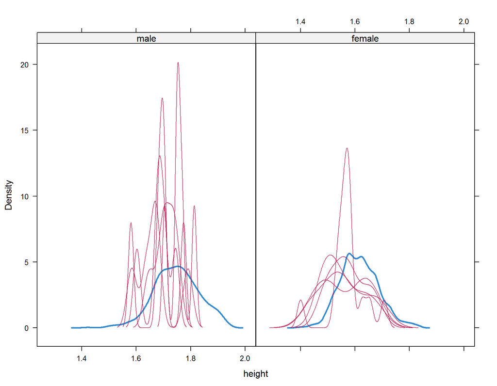

```r
densityplot(imp, ~height|gender)
```

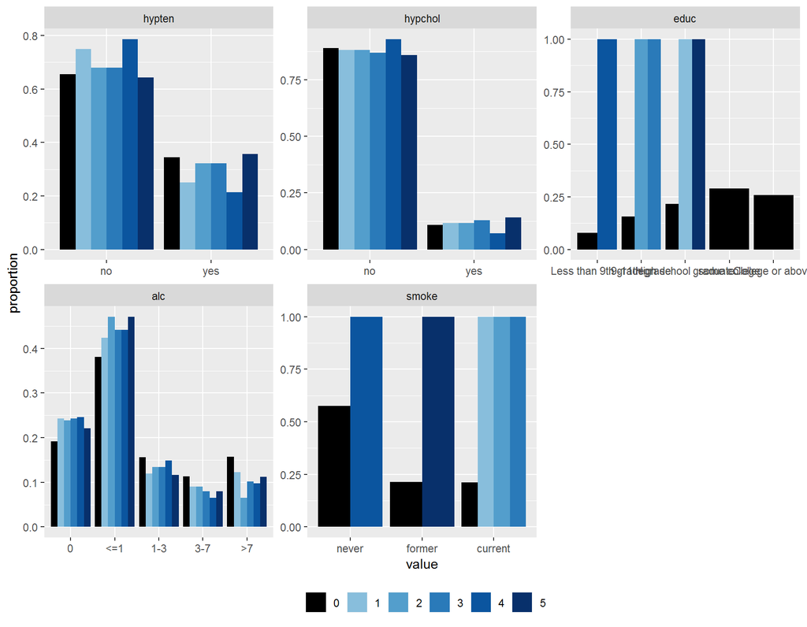

```r
# plot for all categorical variables
probplot(imp)
```

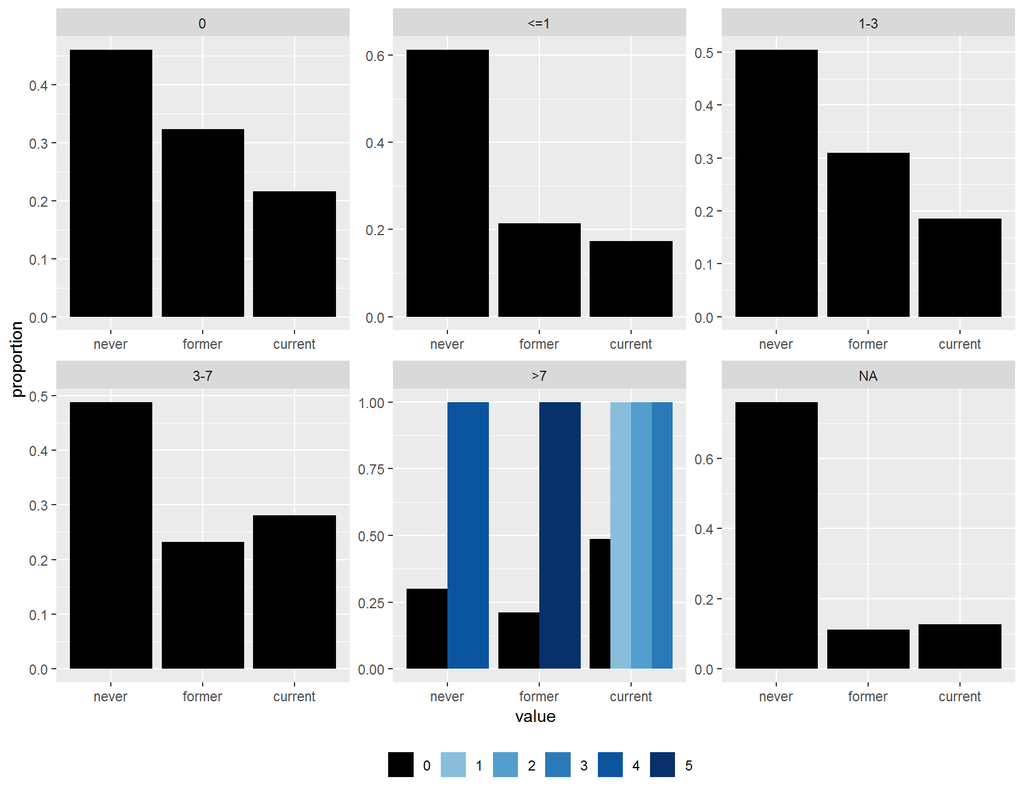

```r
# look into the categorical variables where proportions of imputed and observed differ
probplot(imp, smoke ~ alc)
```

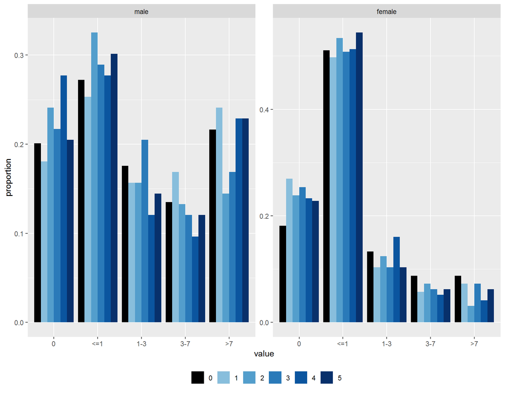

```r
probplot(imp, alc ~ gender)
```

Unfortunately, we have some negative imputed values for `bili`. Often, this would not result in bias in the analysis, but may be difficult to explain when providing a summary of the imputed data in a publication. In the present example we can see that the observed values have a slightly right-skewed distribution, compared to the imputed values. Re-doing the imputation with `pmm` instead of `norm` for `bili` should fix this. (However, since the imputations seem fine overall, and there is little knowledge gain in re-doing the previous steps, we will skip this repetition in this practical.)

The distributions of the imputed values for `height` and `SBP` differ a bit from the distributions of the observed data, but these differences can be explained by adjusting for `gender` and `hypten`.

The difference in distribution of `alc` could be explained by `gender`. `smoke` and `educ` each have only one missing value, which makes it difficult to judge the distribution of imputed values. Adjusting the distributions of observed `smoke` for `alc` shows that the subject with missing smoking status was a drinker, and drinkers were more often in the `current` group of smoking.

## Analysis

### Fitting models on `mids` objects

When we are confident that the imputation was successfull, the imputed data can be analysed with any complete data method.

#### Task

Choose any analysis model of interest and fit it on the imputed data. The model could for instance be a linear regression model (using `lm`) or a generalized linear regression model, e.g., logistic regression (using `glm()`). Find out the `class` and structure of the resulting object.

`imp` is not a dataframe but an object of class `mids`, so we cannot use the normal specification of a model in which we specify the argument `data` to be a `data.frame`. Instead, use `with(imp, <model function without data>)`.

#### Solution

```r
# for example:
models1 <- with(imp, lm(SBP ~ age + gender + bili + chol + BMI))
models2 <- with(imp, glm(hypchol ~ age + gender + bili + race + BMI,
                       family = "binomial"))
models3 <- with(imp, glm(creat ~ age + gender + uricacid + WC + BMI,
                       family = Gamma(link = 'log')))
```

```r
# to determine the class
class(models1)
```

```
## [1] "mira"   "matrix"
```

```r
# to determine the structure
names(models1)
```

```
## [1] "call"     "call1"    "nmis"     "analyses"
```

```r
lapply(models1, class)
```

```
## $call
## [1] "call"
##
## $call1
## [1] "call"
##
## $nmis
## [1] "integer"
##
## $analyses
## [1] "list"
```

```r
# explore further
models1$analyses
```

```
## [[1]]
##
## Call:
## lm(formula = SBP ~ age + gender + bili + chol + BMI)
##
## Coefficients:
##  (Intercept)           age  genderfemale          bili          chol
##     96.86237       0.43508      -6.50909      -1.77685       0.02526
##          BMI
##      0.28074
##
##
## [[2]]
##
## Call:
## lm(formula = SBP ~ age + gender + bili + chol + BMI)
##
## Coefficients:
##  (Intercept)           age  genderfemale          bili          chol
##      96.0693        0.4259       -6.1581       -2.1382        0.2462
##          BMI
##       0.2888
##
##
## [[3]]
##
## Call:
## lm(formula = SBP ~ age + gender + bili + chol + BMI)
##
## Coefficients:
##  (Intercept)           age  genderfemale          bili          chol
##      94.5465        0.4262       -6.4878       -1.0444        0.4330
##          BMI
##       0.2952
##
##
## [[4]]
##
## Call:
## lm(formula = SBP ~ age + gender + bili + chol + BMI)
##
## Coefficients:
##  (Intercept)           age  genderfemale          bili          chol
##      94.4970        0.4349       -6.2229       -0.9663        0.5268
##          BMI
##       0.2508
##
##
## [[5]]
##
## Call:
## lm(formula = SBP ~ age + gender + bili + chol + BMI)
##
## Coefficients:
##  (Intercept)           age  genderfemale          bili          chol
##      96.0681        0.4338       -6.3130       -1.5191        0.2326
##          BMI
##       0.2697
```

```r
summary(models1$analyses[[1]])
```

```
##
## Call:
## lm(formula = SBP ~ age + gender + bili + chol + BMI)
##
## Residuals:
##     Min      1Q  Median      3Q     Max
## -41.953  -9.706  -0.840   8.343  74.661
##
## Coefficients:
##              Estimate Std. Error t value Pr(>|t|)
## (Intercept)  96.86237    3.62304  26.735  < 2e-16 ***
## age           0.43508    0.02842  15.311  < 2e-16 ***
## genderfemale -6.50909    0.96083  -6.774 2.14e-11 ***
## bili         -1.77685    1.64349  -1.081 0.279896
## chol          0.02526    0.45953   0.055 0.956176
## BMI           0.28074    0.07595   3.696 0.000231 ***
## ---
## Signif. codes:  0 '***' 0.001 '**' 0.01 '*' 0.05 '.' 0.1 ' ' 1
##
## Residual standard error: 14.7 on 994 degrees of freedom
## Multiple R-squared:  0.2362, Adjusted R-squared:  0.2323
## F-statistic: 61.47 on 5 and 994 DF,  p-value: < 2.2e-16
```

### Structure of `mira` objects

Analyses performed on `mids` objects will result in a `mira` object (multiply imputed repeated analyses).

A `mira` object is a list with the following elements:

| `call`: | The call that created the `mira` object. |
| --- | --- |
| `call1`: | The call that created the `mids` object. |
| `nmis`: | The number of missing observations per column. |
| `analyses`: | The models fitted on each of the imputed datasets: A list with `imp$m` components, where each component contains a fitted model object. |

The class of each of the components of `imp$analyses` will depend on the type of model that was fitted.

## Pooling

### Combining results

To pool the results from the repeated analyses contained in a `mira` object, the function `pool()` can be used.

#### Task

Pool one of the provided `mira` objects (`models1`, `models2` or `models3`) and investigate its structure.

#### Solution

```r
# pool the model
pooled1 <- pool(models1)

# investigate the structure
class(pooled1)
```

```
## [1] "mipo"       "data.frame"
```

```r
names(pooled1)
```

```
## [1] "call"   "m"      "pooled"
```

```r
str(pooled1)
```

```
## Classes 'mipo' and 'data.frame': 0 obs. of  3 variables:
##  $ call  : language pool(object = models1)
##  $ m     : int 5
##  $ pooled:'data.frame':  6 obs. of  9 variables:
##   ..$ estimate: num  95.609 0.431 -6.338 -1.489 0.293 ...
##   ..$ ubar    : num  1.31e+01 8.08e-04 9.21e-01 2.65 2.14e-01 ...
##   ..$ b       : num  1.089759 0.000022 0.02449 0.244011 0.037952 ...
##   ..$ t       : num  1.44e+01 8.35e-04 9.51e-01 2.94 2.59e-01 ...
##   ..$ dfcom   : int  994 994 994 994 994 994
##   ..$ df      : num  316 774 782 278 112 ...
##   ..$ riv     : num  0.0997 0.0327 0.0319 0.1105 0.213 ...
##   ..$ lambda  : num  0.0906 0.0317 0.0309 0.0995 0.1756 ...
##   ..$ fmi     : num  0.0963 0.0342 0.0334 0.1059 0.19 ...
```

### Structure of `mipo` objects

Pooling of a `mira` object results in a `mipo` object (multiply imputed pooled analysis).

The `mipo` object is a list that has the following elements:

| `call`: | The call that created the `mipo` object. |
| --- | --- |
| `call1`: | The call that created the `mids` object. |
| `call2`: | The call that created the `mira` object. |
| `data` | The original, incomplete data. |
| `nmis`: | The number of missing values per variable. |
| `m`: | The number of imputations. |
| `qhat`: | The coefficients from all analyses: a matrix with `m` rows and `npar`columns. |
| `u`: | The variance-covariance matrix of the coefficients from each analysis: an array of dimension `c(m, npar, npar)`. |
| `qbar`: | The pooled parameter estimates: a vector of length `npar`. |
| `ubar`: | The average within imputation variance: a matrix with `npar` rows and `npar` columns containing the averaged variance-covariance matrices. |
| `b`: | The between imputation variance-covariance matrix ($u + b + b/m$). |
| `t`: | The total variance-covariance matrix. |
| `r`: | The relative increase in variance due to the missing values. |
| `dfcom`: | Degrees of freedom in the hypothetically complete data (`N - # free parameters`). |
| `df`: | Degrees of freedom associated with the $t$-statistics. |
| `fmi`: | Fraction of missing information. |
| `lambda`: | Proportion of the variation due to the missing values: $(b+b/m)/t$. |

From the elements contained in the `mipo` object, we could obtain the pooled coefficients (`qbar`) and variances (`t`), and calculate the pooled confidence intervals and p-values by hand, using the function provided in the course notes.

However, the function `summary()` applied to the `mipo` object will do this for us.

**Note:**  
`pool()` extracts the model coefficients and variance-covariance matrices using the functions `coef()` and `vcov()`. Hence, pooling using the `pool()` function from **mice** only works for those types of models for which these functions will return the regression coefficients and corresponding variance-covariance matrix.

Moreover, `pool()` only works for objects of class `mira`. When data has been imputed in a different package/software, or analyses have not been performed in the way described above, a list of fitted models can be converted to a `mira` object using `as.mira()`.

#### Task

Get the summary of the pooled results.

#### Solution

```r
pooled1 <- pool(models1)
summary(pooled1)
```

|  | estimate | std.error | statistic | df | p.value |
| --- | --- | --- | --- | --- | --- |
| (Intercept) | 95.6086630 | 3.79866752 | 25.1690000 | 316.2804 | 0.000000e+00 |
| age | 0.4311802 | 0.02889521 | 14.9222011 | 774.1458 | 0.000000e+00 |
| genderfemale | -6.3381608 | 0.97498622 | -6.5007696 | 781.7645 | 1.423501e-10 |
| bili | -1.4889898 | 1.71512216 | -0.8681538 | 278.0417 | 3.855766e-01 |
| chol | 0.2927838 | 0.50924766 | 0.5749340 | 111.9457 | 5.655014e-01 |
| BMI | 0.2770378 | 0.07883688 | 3.5140633 | 514.7089 | 4.666806e-04 |

**You have reached the end of this practical. Well done!**